# 1.2. Multiple Linear Regression

Simple linear regression can easily be extended to include multiple features. This is called **Multiple Linear Regression**:

$y = \beta_0 + \beta_1X_1 + ... + \beta_kX_n$

Each $X$ represents a different feature, and each feature has its own coefficient.

```python
# importing libraries
import pandas as pd
import numpy as np

import matplotlib.pyplot as plt
import seaborn as sns

# allow plots to appear directly in the notebook
%matplotlib inline
```

## Example: Advertising Data

```python
# read data into a DataFrame
data = pd.read_csv('./Advertising.csv', index_col=0)
data.head()
```

|  | TV | Radio | Newspaper | Sales |
| --- | --- | --- | --- | --- |
| 1 | 276.12 | 45.36 | 83.04 | 26.52 |
| 2 | 53.40 | 47.16 | 54.12 | 12.48 |
| 3 | 20.64 | 55.08 | 83.16 | 11.16 |
| 4 | 181.80 | 49.56 | 70.20 | 22.20 |
| 5 | 216.96 | 12.96 | 70.08 | 15.48 |

```python
# print the shape of the DataFrame
data.shape
```

```
(200, 4)
```

```python
# number of null values
data.info()
```

```
<class 'pandas.core.frame.DataFrame'>
Int64Index: 200 entries, 1 to 200
Data columns (total 4 columns):
 #   Column     Non-Null Count  Dtype
---  ------     --------------  -----
 0   TV         200 non-null    float64
 1   Radio      200 non-null    float64
 2   Newspaper  200 non-null    float64
 3   Sales      200 non-null    float64
dtypes: float64(4)
memory usage: 7.8 KB
```

What are the **features** i.e., **X**?

- TV: advertising dollars spent on TV for a single product in a given market (in thousands of dollars)
- Radio: advertising dollars spent on Radio
- Newspaper: advertising dollars spent on Newspaper

What is the **response** i.e., **y**?

- Sales: sales of a single product in a given market (in thousands of widgets)

What else do we know?

- Because the response variable is continuous, this is a regression problem.
- Since we will be considering all the feature varibles in our model, this is a Multiple Linear Regression problem specifically.

Thus, in this case:

$$y = \beta_0 + \beta_1 * TV + \beta_2 * Radio + \beta_3 * Newspaper$$

There are 200 **observations**, and thus 200 markets in the dataset.

### Checking Linear Relationship

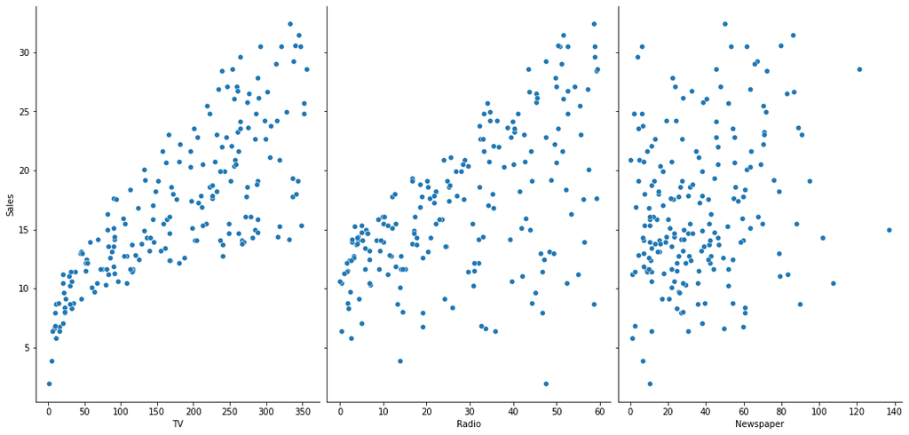

```python
# visualize the relationship between the features and the response using scatterplots
sns.pairplot(data, x_vars=['TV','Radio','Newspaper'], y_vars='Sales', height=7, aspect=0.7)  # aspect controls the size graphs

## plotting scatterplots with the line of best fit
# sns.pairplot(data, x_vars=['TV','Radio','Newspaper'], y_vars='Sales', height=7, aspect=0.7, kind='reg')
```

Conclusion:

- Strong relationship between TV ads and sales
- Weak relationship between Radio ads and sales
- Very weak relationship between Newspaper ads and sales

Let's estimate the model coefficients for the advertising data:

### Preparing X and y using pandas

**Remember:**

- scikit-learn expects X (feature matrix) and y (response vector) to be NumPy arrays
- However, pandas is built on top of NumPy
- Thus, X can be a pandas DataFrame (matrix) and y can be a pandas Series (vector)

```python
# declaring independent variable X & dependent vriable y

# create a Python list of feature names
feature_cols = ['TV', 'Radio', 'Newspaper']

# use the list to select a subset of the original DataFrame
X = data[feature_cols]

# equivalent command to do this in one line using double square brackets i.e., X = data[['TV', 'Radio', 'Newspaper']]
# inner bracket is a list
# outer bracker accesses a subset of the original DataFrame


# select target variable from the DataFrame
y = data['Sales']
```

```python
# check the shape of X and y
print(X.shape)
print(y.shape)
```

```
(200, 3)
(200,)
```

### Splitting X and y into training and testing sets

```python
# importing module for splitting the data

from sklearn.model_selection import train_test_split

X_train, X_test, y_train, y_test = train_test_split(X, y, random_state = 1) #unpacking, default splitting ratio is 75:25
```

```python
# default split is 75% for training and 25% for testing
print(X_train.shape)
print(X_test.shape)
print(y_train.shape)
print(y_test.shape)
```

```
(150, 3)
(50, 3)
(150,)
(50,)
```

### Fitting MLR model on training dataset

```python
# import model
from sklearn.linear_model import LinearRegression

# instantiate
linreg = LinearRegression()

# fit the model to the training data (learn the coefficients)
linreg.fit(X_train, y_train)
```

```
LinearRegression(copy_X=True, fit_intercept=True, n_jobs=None, normalize=False)
```

### Get Coefficients

```python
# print the intercept and coefficients
print(linreg.intercept_)
print(linreg.coef_)
```

```
3.4523599467815167
[0.04656457 0.17915812 0.00345046]
```

```python
# pair the feature names with the coefficients

for i,j in zip(feature_cols, linreg.coef_):
#     print (i,':',round(j,3))
    print (i,':',j)
```

```
TV : 0.04656456787415028
Radio : 0.17915812245088847
Newspaper : 0.0034504647111804343
```

How do we interpret these coefficients?

- For a given amount of Radio and Newspaper ad spending, a "unit" increase in TV ad spending is associated with a 0.04656 "unit" increase in Sales. Or more clearly, for a given amount of Radio and Newspaper ad spending, an increase of $1,000 spent on TV ads will lead to an increase in sales by around 46.56 uints (0.04656 * 1000).
- Similary, for a given amount of TV & Newspaper ad spending, then an increase of $1000 in Radio ad spending will lead to an increase in sales by around 179 units (0.1791 * 1000).
- However, for the newspaper budget, since the coefficient is quite negligible (close to zero), it’s evident that the newspaper is not affecting the sales.

### Make predictions on test dataset

```python
# make predictions on the testing set
y_pred = linreg.predict(X_test)
```

### Model Evaluation

**Mean Absolute Error** (MAE) is the mean of the absolute value of the errors:

$$\frac 1n\sum_{i=1}^n|y_i-\hat{y}_i|$$

**Mean Squared Error** (MSE) is the mean of the squared errors:

$$\frac 1n\sum_{i=1}^n(y_i-\hat{y}_i)^2$$

**Root Mean Squared Error** (RMSE) is the square root of the mean of the squared errors:

$$\sqrt{\frac 1n\sum_{i=1}^n(y_i-\hat{y}_i)^2}$$

Let's calculate these, to get an intuitive sense for the results:

```python
# import module to be used for model evaluation

from sklearn import metrics
```

```python
# Mean Absolute Error (MAE)
print("Mean absolute error (MAE):", metrics.mean_absolute_error(y_test,y_pred))
```

```
Mean absolute error (MAE): 1.2802700499114252
```

```python
# Mean Squared Error
print("Mean square error (MSE):", metrics.mean_squared_error(y_test,y_pred))
```

```
Mean square error (MSE): 2.8411856931288044
```

```python
# Root Mean Squared Error
print("Root mean square error (RMSE):", np.sqrt(metrics.mean_squared_error(y_test,y_pred)))
```

```
Root mean square error (RMSE): 1.6855817076394737
```

### R^2 (R-squared)

```python
# R2

print("R-squared value of predictions:",metrics.r2_score(y_test,y_pred))
```

```
R-squared value of predictions: 0.9156213613792233
```

```python
#cross-checking

df_check = pd.DataFrame({'Actual': y_test[:10].values, 'Predicted': y_pred[:10].ravel()})
df_check
```

|  | Actual | Predicted |
| --- | --- | --- |
| 0 | 28.56 | 26.050924 |
| 1 | 19.92 | 19.692663 |
| 2 | 11.40 | 9.131461 |
| 3 | 17.76 | 21.369235 |
| 4 | 21.12 | 22.337563 |
| 5 | 30.60 | 28.602888 |
| 6 | 20.28 | 19.589864 |
| 7 | 15.48 | 16.118706 |
| 8 | 12.60 | 11.006081 |
| 9 | 20.52 | 20.800624 |

### 1. Linearity

Linear regression needs the relationship between the independent and dependent variables to be linear. Let's use a pair plot to check the relation of independent variables with the Sales variable

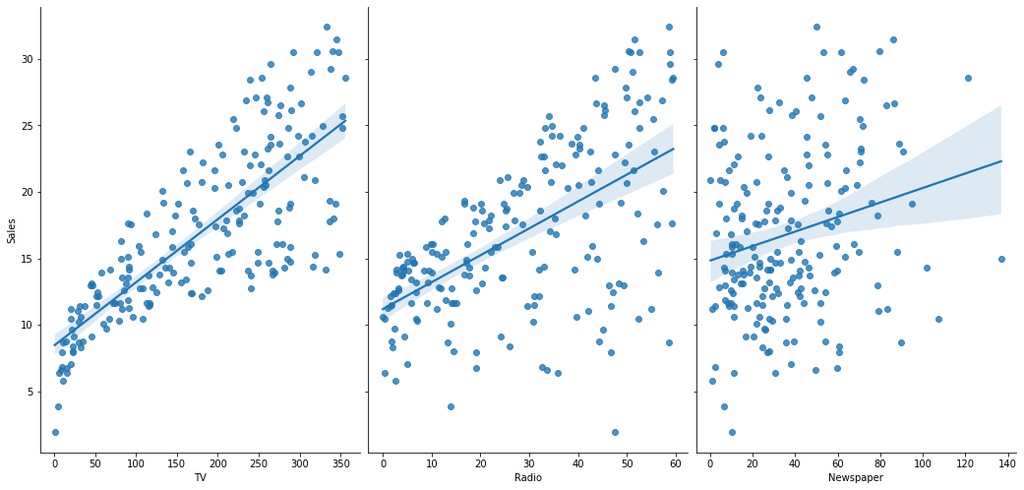

```python
sns.pairplot(data, x_vars=['TV','Radio','Newspaper'], y_vars='Sales', height=7, aspect=0.7, kind='reg')
```

By looking at the plots we can see that with the Sales variable the none of the independent variables form an accurately linear shape but TV and Radio do still better than Newspaper which seems to hardly have any specific shape.

### 2. Multicollinearity

In regression, multicollinearity refers to the extent to which independent variables are correlated.

```python
# correlation matrix
data.corr()
```

|  | TV | Radio | Newspaper | Sales |
| --- | --- | --- | --- | --- |
| TV | 1.000000 | 0.054809 | 0.056648 | 0.782224 |
| Radio | 0.054809 | 1.000000 | 0.354104 | 0.576223 |
| Newspaper | 0.056648 | 0.354104 | 1.000000 | 0.228299 |
| Sales | 0.782224 | 0.576223 | 0.228299 | 1.000000 |

- Look for correlation of rows where the dependent variable (Sales in this case) is not involved because if a variable is correlated with the dependent variable then this would be a good sign for our model.
- Correlation within dependent variables is what we need to look for and avoid.

This data doesn't contain perfect multicollinearity among independent variables. In case there was any then we would try to remove one of the correlated variables depending on which was more important to our regression model.

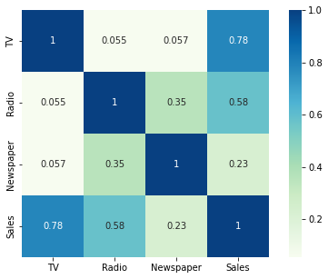

```python
# heatmap of correlation matrix

plt.figure(figsize=(8,5))
sns.heatmap(data.corr(), annot=True,cmap='GnBu',square=True)
```

The thing worth noticing here is that the correlation between newspaper and radio is 0.35. This indicates a fair relationship between newspaper and radio budgets. Hence, it can be inferred that : when the radio budget is increased for a product, there’s a tendency to spend more on newspapers as well.

This is called collinearity and is referred to as a situation in which two or more input variables are linearly related. Hence, even though the Multiple Regression model shows no impact on sales by the newspaper, the Simple Regression model still does due to this multicollinearity and the absence of other input variables.

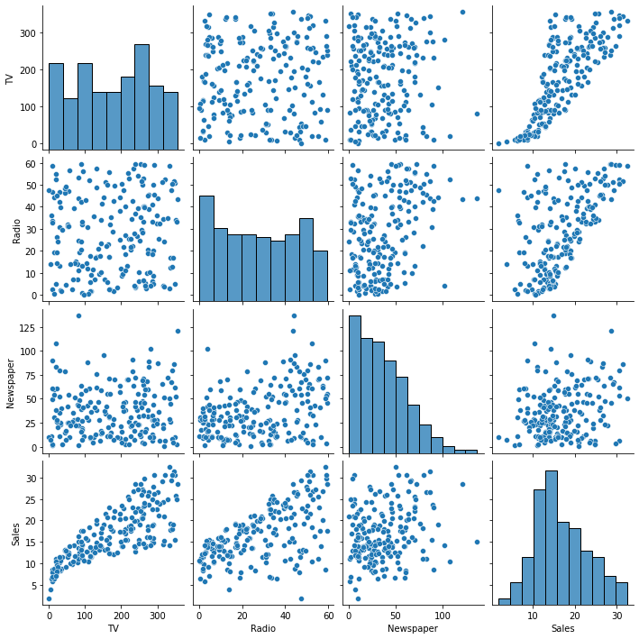

```python
#scatterplots for pairs

sns.pairplot(data)
```

### 3. Residual Analysis

Residuals must be Normally distributed with mean zero.

```python
## first compute vector of residuals.
resids = np.subtract(y_test, y_pred)
```

```python
mean_resids = np.mean(resids)
print("Mean of Residuals:",mean_resids)
```

```
Mean of Residuals: 0.12097366350936181
```

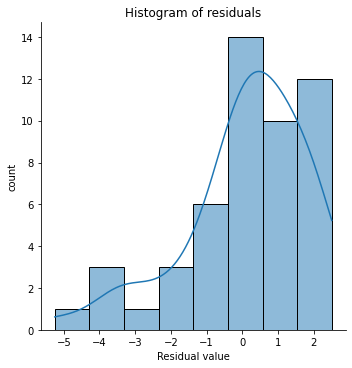

```python
## now make the residual plots
sns.displot(resids, kde = True)
plt.title('Histogram of residuals')
plt.xlabel('Residual value')
plt.ylabel('count')
```

- Mean of Residuals is very close to zero so all good here.
- The residual terms are pretty much normally distributed. A skew is also visible from the plot. Remember that, it's very difficult to get perfect normal curve in real life data. We are also giving it a benifit of doubt because of the number of test points we took, which is very small (just 50).

### 4. Homoscedasticity

Homoscedasticity means that the residuals have equal or almost equal variance across the regression line. By plotting the error terms with predicted terms we can check that there should not be any pattern in the error terms.

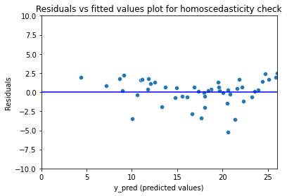

```python
#predictions plot vs residual

sns.scatterplot(x = y_pred,y = resids)
sns.lineplot([0,26],[0,0],color='blue')

plt.ylim(-10,10)
plt.xlim(0,26)

plt.xlabel('y_pred (predicted values)')
plt.ylabel('Residuals')
plt.title('Residuals vs fitted values plot for homoscedasticity check')
plt.show()
```